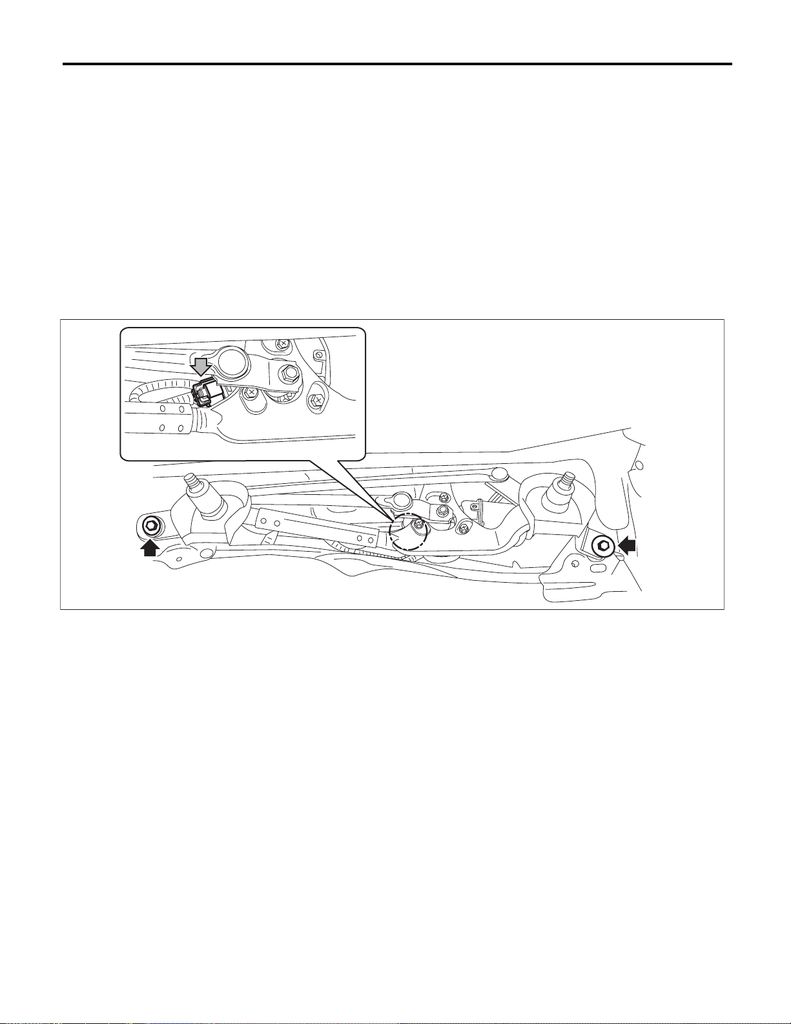

WW-21

Front Wiper Motor and Link

WIPER AND WASHER SYSTEMS

8. Front Wiper Motor and Link

A: REMOVAL

1) Disconnect the ground cable from battery. <Ref. to NT-5, BATTERY, NOTE, Note.>

NOTE:

For models other than STI model, disconnect the ground terminal from battery sensor.

2) Remove the arm assembly - windshield wiper. <Ref. to WW-19, REMOVAL, Front Wiper Arm.>

3) Remove the cowl panel - side and the cowl panel assembly. <Ref. to EI-45, REMOVAL, Cowl Panel.>

CAUTION:

Before removing the cowl panel, use an air blower and nylon brush to sweep gravel from the lower

area of the front side of the glass.

4) Remove the link assembly - windshield wiper.

(1) Disconnect the connector of the motor assembly - windshield wiper.

(2) Remove the bolts and harness clips, and remove the link assembly - windshield wiper.

WW-01149

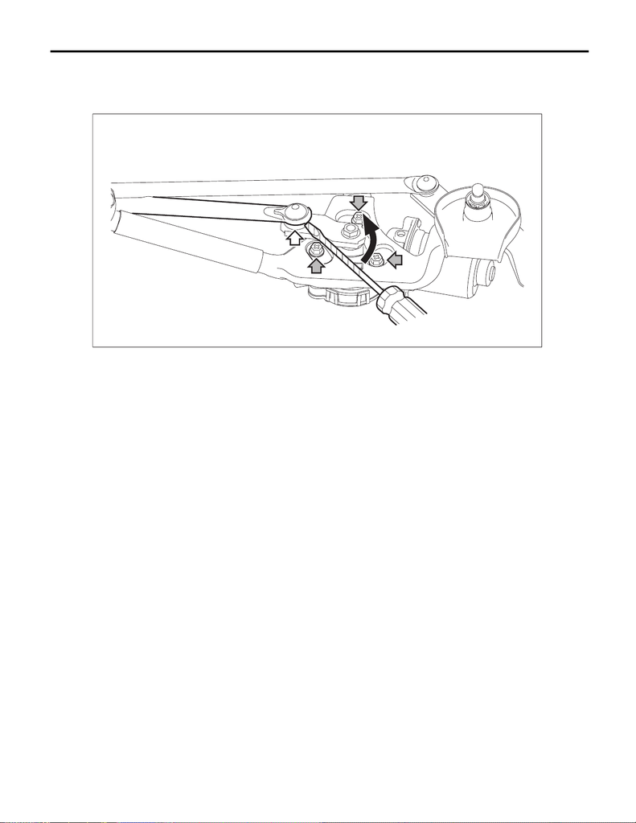

WW-22

Front Wiper Motor and Link

WIPER AND WASHER SYSTEMS

5) Remove the motor assembly - windshield wiper.

(1) Using a flat tip screwdriver wrapped with protective tape, disconnect the link assembly - windshield

wiper from the link plate.

(2) Remove the bolts, and remove the motor assembly - windshield wiper.

B: INSTALLATION

CAUTION:

Before installing the windshield glass and the cowl panel, make sure there is no gravel in the install-

ing area.

1) Connect the battery ground terminal. <Ref. to NT-5, BATTERY, NOTE, Note.>

NOTE:

For models other than STI model, connect the ground terminal to battery sensor.

2) Check that the motor assembly - windshield wiper is at the auto stop position.

CAUTION:

During motor operation, do not touch the movable part.

(1) Connect the harness of front wiper to the motor assembly - windshield wiper.

(2) Switch the wiper switch to ON/OFF once.

3) Disconnect the ground cable from battery again. <Ref. to NT-5, BATTERY, NOTE, Note.>

NOTE:

For models other than STI model, disconnect the ground terminal from battery sensor.

4) Install the motor assembly - windshield wiper.

Tightening torque:

5.5 N·m (0.6 kgf-m, 4.1 ft-lb)

WW-01221

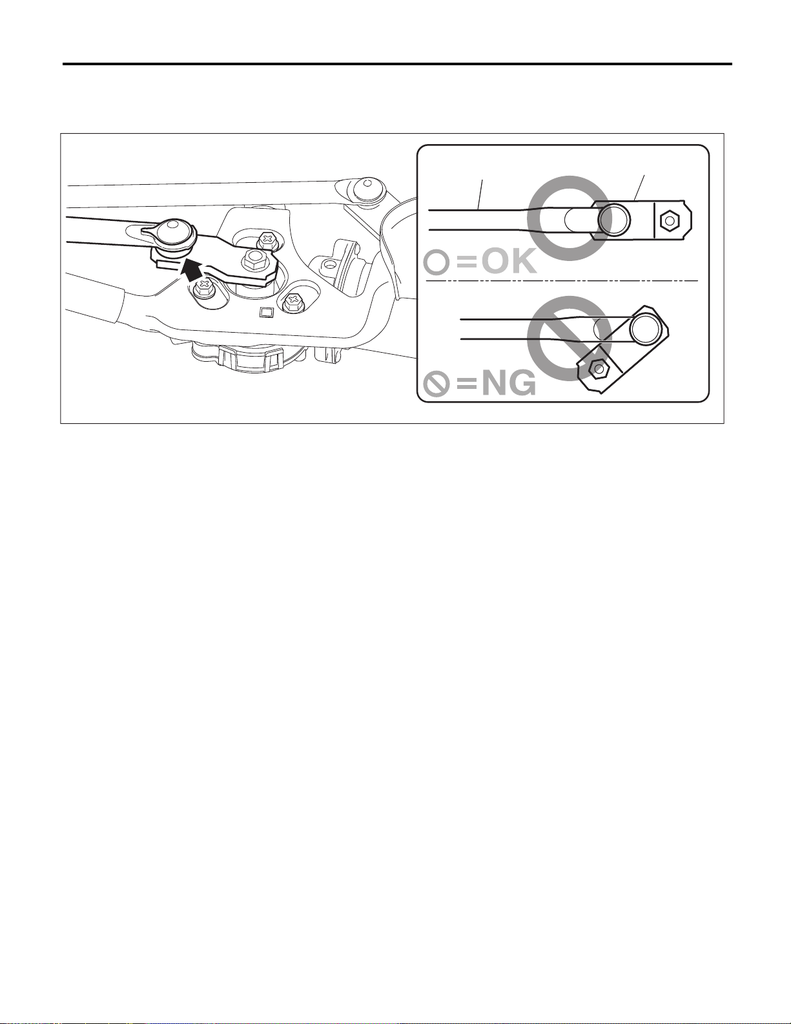

WW-23

Front Wiper Motor and Link

WIPER AND WASHER SYSTEMS

CAUTION:

Set the component where the rod (B) and link plate (A) are aligned in a straight line.

Tightening torque:

6 N·m (0.6 kgf-m, 4.4 ft-lb)

7) Install the cowl panel - side and the cowl panel assembly. <Ref. to EI-46, INSTALLATION, Cowl Panel.>

NOTE:

For models other than STI model, connect the ground terminal to battery sensor.

10) Check the position of windshield wiper. <Ref. to WW-20, ADJUSTMENT, Front Wiper Arm.>

WW-01155

(A)

(B)

(A)

(B)

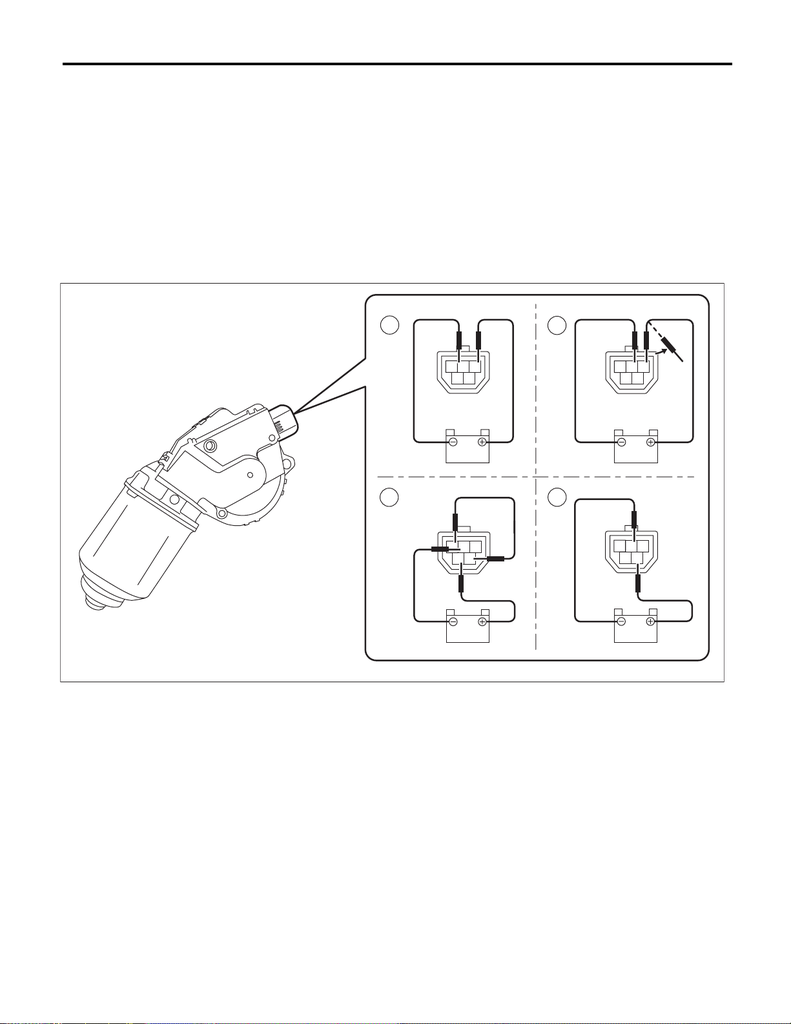

WW-24

Front Wiper Motor and Link

WIPER AND WASHER SYSTEMS

C: INSPECTION

1) Check that the following operations perform normally.

CAUTION:

Fix the motor to prevent the motor from being shorted by moving during operation.

(1) When the battery is connected to the terminal of connectors, confirm that the motor operates at low

speed.

(2) When the battery is connected to the terminal of connectors, confirm that the motor operates at high

speed.

(3) Connect the battery to terminals of the connector, and remove the terminal connection with motor ro-

tating at low speed, and stop the motor assembly - windshield wiper in mid-operation.

(4) Connect the battery and check that the motor stops at the automatic stop position after the motor op-

erates at low speed again.

NOTE:

Replace the motor assembly - windshield wiper if the inspection result is not within the standard value.

2) Install the motor assembly - windshield wiper. <Ref. to WW-22, INSTALLATION, Front Wiper Motor and

Link.>

WW-00890

1

2

3

4

3 2

5 4

1

3 2

5 4

1

3 2

5 4

1

3 2

5 4

1